# Select R Shiny Topics and Examples

Ryan Miller

## Outline

The presentation has three goals:

1. Reinforce and expand upon key concepts introduced in RStudio’s R Shiny tutorial
2. Provide workflow advice to lessen your headaches when creating an app
3. Introduce a handful of R Shiny features that previous students have found useful

## Review of the Basics

- An R Shiny app contains two components:
  - **server**: a function that *listens* for changes in **inputs** and translates them into **outputs**
    - Typical inputs are names of variables use or conditions to filter by
    - Typical outputs are graphics or tables
  - **ui**: a user interface that allows inputs to be changed and displays the resulting output

```r
library(shiny)

ui <- fluidPage(
  ## The user interface is created here
)

server <- function(input, output) {
  ## Code translating inputs to outputs goes here
}
```

**Workflow Tip #1**:

- List your desired inputs and outputs *before* you write any code
- Then, use an R Script (outside of the R Shiny environment!) to confirm that you can create your desired outputs (from your inputs) without any errors

## The UI

- The R Shiny UI is just an HTML page, meaning you can use HTML commands within `fluidPage` (or other functions)
  - In fact, the functions `titlePanel` and `sidebarLayout` are actually just wrappers for HTML code (which is why you’ll often see these functions nested)
- A UI feature used by many previous students are “Tabsets”
  - [This Link](https://shiny.rstudio.com/gallery/tabsets.html) shows a simple example
  - [The Shiny Cheatsheet](https://shiny.rstudio.com/images/shiny-cheatsheet.pdf) shows a couple of alternatives in the “Layouts” section on the second page

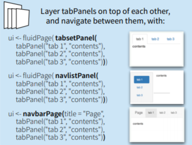

**Workflow Tip #2**:

- After determining your inputs and outputs, create a skeleton of your UI
  - You should fully format your inputs, but leave placeholders for where the output will go

## The Server

- The server function is defined to include two list objects named “input” and “output”

```r
server <- function(input, output) {

  output$myPlot <- renderPlot({
              ggplot(myData, aes(x = x, y = y))
  })

}
```

- Objects you build within the server function need to be saved as elements of “output” using a `render_` function
  - Examples include `renderPlot`, `renderPlotly`, `renderLeaflet`, and `renderTable`
  - One of the most common mistakes is using the wrong `render_` function

**Workflow Tip #3**:

- Test out creating the objects you’ll use in `render_` outside of the shiny environment so you can be certain they are being created correctly.
- It is difficult and time consuming to debug `ggplot`, `plotly`, or `leaflet` using the error messages given by R Shiny

## Reactivity

- In order for users to interact with your app its outputs need to **react** to changes in inputs

```r
x <- 1
y <- x + 2
x <- 5
```

- In normal progamming, this code would result in `x` being 5 and `y` being 3
- In reactive programming, `x` is 5 but `y` is now 7
  - A change in `x` will cause *all commands* that include `x` to “react” and be re-run using the updated value of `x`

## Reactivity

- All of the `render_` functions are reactive (meaning they will re-run whenever anything used inside of them changes)
  - To make your life easier, I encourage you to put as much as you can inside of these functions
- Sometimes trying to put all of your code inside of `render_` functions leads to reduncancy
  - One way to avoid this using the `reactive` function, visit [this link](https://deanattali.com/blog/building-shiny-apps-tutorial/#10-reactivity-101) for more on reactivity

**Workflow Tip #4**:

- Let `render_` functions manage reactivity for you by putting all (or most) of your code inside these functions
  - Consider using a [submit button](https://shiny.rstudio.com/reference/shiny/latest/submitButton.html) in your UI if re-running your `render_` functions everytime an input changes makes your app laggy
  - Consider using the `reactive` function only if you think reduncancies are causing your app to run slowly

## Other Commonly Used Features

- Dynamic UI
  - Sometimes you want your inputs/UI to change in accordance with earlier inputs
  - For example, you might want the option to apply a log transformation *only* if the selected variable is numeric
  - This can be done using [Dynamic UI](https://shiny.rstudio.com/articles/dynamic-ui.html)
- `selectizeInput`
  - Sometimes you want the user to be able to start typing a text input with auto-complete options show they don’t need to provide a perfect match
  - This input box can be created using [Selectize](https://shiny.rstudio.com/articles/selectize.html)
- Converting between variable names and text strings
  - Often you’ll have an input that is character string (ie: “myVar”) that you want to use to reference a variable
  - The `get` function will return the object with the name you provide as a string
  - For example, `get(input$myChoice)` will return the variable with the same name as the character string stored in “input$myChoice”

## Recap of Workflow Advice

1. Plan your inputs and outputs before starting on your app
2. Make sure you can create your outputs (from your inputs) without errors in an ordinary R Script
3. Create your UI first, leaving blank spaces for your outputs
4. Place as much of your server code as possible inside of `render_` functions
5. Save working versions of your app in a seperate file at regular intervals. It is very easy to break a Shiny app, so it is often useful to revert to the most working version of your app when trying to debug errors.